# La política institucional chilena y acción política post estallido: el valor de la democracia desde una perspectiva generacional en tiempos de crisis

Sociología UAH / Prof. Valentina Andrade /Ayudantes: Nicolas Godoy & Dafne Jaime

Javier Ortiz Iturra

22-11-2021

### Resumen

En este trabajo pretendemos problematizar el socavamiento de lo que se comprende como democracia deliberativa, principalmente desde su producto: el voto; cómo también de sus representaciones institucionales: los partidos políticos. Mas específicamente, nos referiremos a la situación de la democracia chilena en contexto de crisis post “estallido social” y cómo se evalúa generacionalmente la democracia, desde la política institucional y desde la acción política ligada a la protesta social.

### Introducción

Hoy en día, lo que entendemos y practicamos como democracia, se asemeja bastante a las ideas de Habermas, respecto de lo que se comprende como democracia deliberativa. La practica de la democracia deliberativa, presupone la existencia de ciudadanos, quienes a través de procesos del lenguaje pueden llegar a un entendimiento y así poder comprender la complejidad de la esfera pública, debido a la multiplicidad de sistemas sociales que hacen posible el mundo de la vida, tales como: el económico, el político, el cultural, el religioso, el simbólico y el lingüístico, en los que se encuentran atrapados los ciudadanos (Domínguez, 2013). Así se ha construido todo un corpus teórico a partir de la comprensión de la democracia deliberativa como un mecanismo discursivo, en donde el proceso democratico se construye mediante la convergencia de las individualidades en decisiones colectivas (en el mejor de los casos vinculantes), pero que al final desembocan en una decisión individual: el voto.

Entonces podríamos indicar que:

*“La legitimidad de la democracia estriba en la capacidad o la oportunidad que tienen los sujetos de las decisiones colectivas de participar en deliberaciones efectivas; las exigencias tienen que justificarse de modo que la gente, reflexionando sobre ellas, pueda aceptarlas” (Cortina, 2007; pág. 145).*

Desde este punto de partida, en este trabajo pretendemos identificar la evaluación de la democracia en el Chile post estallido social y en plena crisis sociopolítica. Esto desde dos dimensiones de análisis: La política representativa y la acción política ligada a las protestas desde un enfoque generacional.

### Democracia deliverativa y representaciones institucionales de la democracia

El Contexto de crisis social y política de Chile ha tenido una multiplicad de factores que hacen muy difícil su análisis, por sus implicancias temporales, históricas, políticas y por supuesto por sus implicancias social y culturales. Aquí no se pretende abordar un análisis del estallido social, sino de los mecanismos que deberían poder enmendar esta situación, que es más participación democrática. Podríamos indicar que en Chile existe un fuerte distanciamiento de las representaciones institucionales de la política, principalmente desde los partidos políticos con la ciudadanía (Heiss, 2020; Cárdenas et.al, 2007).

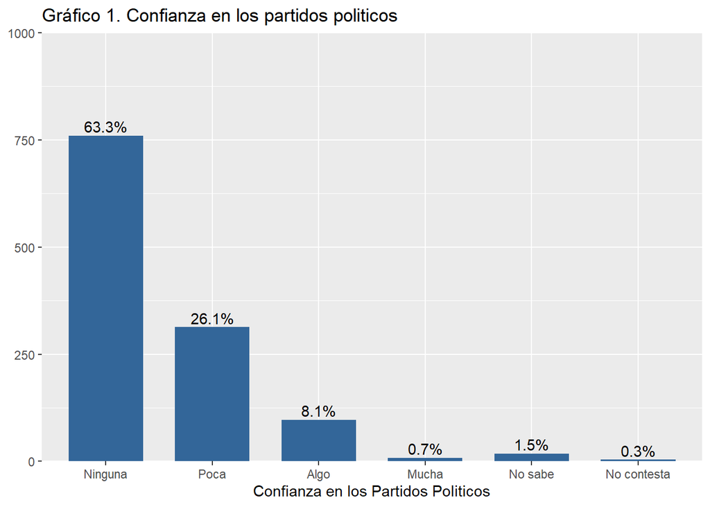

###### Fuente elaboracion propia en base a datos de Latinobarómetro 2020

En este sentido, los mecanismos representativos, normativos o institucionales no dan el ancho ante las demandas de la ciudadanía chilena. La oferta del espectro político ha sufrido una transversal critica de la ciudadanía. Esto ha sido alimentado por los casos de corrupción de la Concertación y la Alianza, que se alzaron como los principales conglomerados políticos desde la vuelta a la democracia en 1990. Esto queda expuesto en el gráfico 1, en donde observamos como el 63% de la ciudadanía chilena no tiene ninguna confianza en los partidos políticos

Tabla 1. Formas para que Chile progrese según tramo de edad

| La mejor forma de actuar para que Ud. y el pais avancen mas | Edad en tramos |  |  | Total |  |
| --- | --- | --- | --- | --- | --- |
|  | Adulto (30 a 59 anos) | Adulto joven (18 a 29 anos) | Adulto mayor (60+) |  |  |
| Hay que votar siempre | 285 47.4 % | 63 23.5 % | 180 68.7 % |  | 528 46.7 % |
| Hay que votar pero tambien protestar | 215 35.8 % | 152 56.7 % | 38 14.5 % | 405 35.8 % |  |
| Solo hay que protestar, no sirve votar | 20 3.3 % | 25 9.3 % | 9 3.4 % | 54 4.8 % |  |
| No hay que hacer nada, ni votar ni protestar | 14 2.3 % | 11 4.1 % | 8 3.1 % | 33 2.9 % |  |
| No hay que hacer nada | 67 11.1 % | 17 6.3 % | 27 10.3 % | 111 9.8 % |  |
| Total | 601 100 % | 268 100 % | 262 100 % | 1131 100 % |  |

### Politica participativa

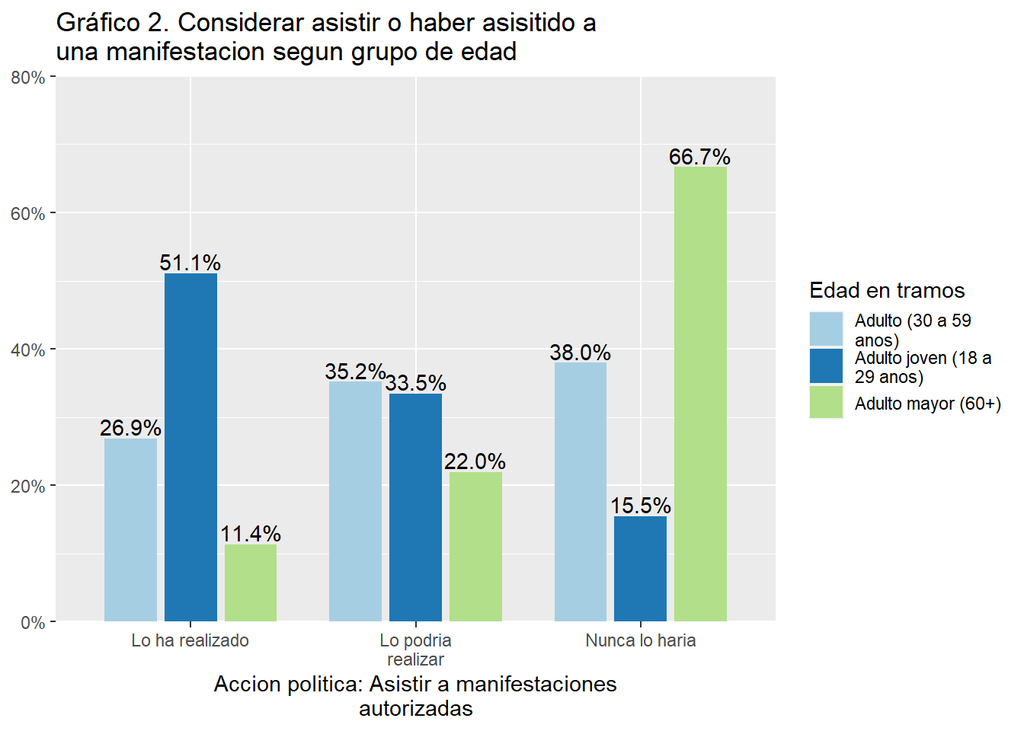

###### Fuente elaboracion propia en base a datos de Latinobarómetro 2020

Al respecto, el grafico 2 demuestra que la mitad de la población adulto joven ha participado de una manifestación, mientras que el 67% de la población adulta mayor no participaría de estas expresiones de la acción política. Hay que tener en cuenta las limitantes físicas de esta población, pero destaca que anteriormente hemos visto que este grupo se inclina por la participación electoral como forma de acción política.

##### Valoracion de la democracia

Hemos podido observar cómo es la tendencia generacional de dos maneras de participación política, ahora nos queda observar cómo es que se varía la valoración de la democracia en función de esta perspectiva generacional.

Tabla 2. Consideraria la llegada de un gobierno autoritario (si soluciona los problemas) según tramo de edad

| No me importaria que un gobierno no democratico llegara al poder si resuelve los problemas | Edad en tramos |  |  | Total |  |
| --- | --- | --- | --- | --- | --- |
|  | Adulto (30 a 59 anos) | Adulto joven (18 a 29 anos) | Adulto mayor (60+) |  |  |
| Muy en desacuerdo | 133 22.5 % | 86 33.6 % | 70 27.5 % |  | 289 26.2 % |
| En desacuerdo | 255 43.1 % | 105 41 % | 93 36.5 % | 453 41.1 % |  |
| De acuerdo | 150 25.3 % | 49 19.1 % | 66 25.9 % | 265 24 % |  |
| Muy de acuerdo | 54 9.1 % | 16 6.2 % | 26 10.2 % | 96 8.7 % |  |
| Total | 592 100 % | 256 100 % | 255 100 % | 1103 100 % |  |

###### Fuente elaboracion propia en base a datos de Latinobarómetro 2020

Tabla 3. Satisfaccion con la democracia según tramo de edad

| Satisfaccion con la democracia | Edad en tramos |  |  | Total |  |
| --- | --- | --- | --- | --- | --- |
|  | Adulto (30 a 59 anos) | Adulto joven (18 a 29 anos) | Adulto mayor (60+) |  |  |
| Nada satisfecho | 154 24.4 % | 78 27.3 % | 65 23.9 % |  | 297 25 % |
| No muy satisfecho | 323 51.3 % | 140 49 % | 149 54.8 % | 612 51.5 % |  |
| Satisfecho | 129 20.5 % | 52 18.2 % | 45 16.5 % | 226 19 % |  |
| Muy satisfecho | 11 1.7 % | 4 1.4 % | 5 1.8 % | 20 1.7 % |  |
| No sabe | 13 2.1 % | 12 4.2 % | 8 2.9 % | 33 2.8 % |  |
| Total | 630 100 % | 286 100 % | 272 100 % | 1188 100 % |  |

###### Fuente elaboracion propia en base a datos de Latinobarómetro 2020

La tabla 3 nos sintetiza la satisfacción generacional de la democracia. Aquí podemos observar una tendencia entre los tres grupos etarios, demostrando que el fortalecimiento de la democracia es un desafío sumamente complejo en la sociedad chilena y que es menester del Estado, de las instituciones públicas, de la clase política, como también de los mismos ciudadanos el poder fortalecerla.

### Conlcusiones

La democracia chilena muestra diferentes tendencias desde la óptica de los grupos generacionales. Los más jóvenes siguen la lógica participativa y formas de acción política mas contestatarias que sus compatriotas más longevos. Pero, dentro de todo, la democracia deliberativa representada por el voto, no parece una opción demasiado debilitada, el problema parecieran ser los partidos políticos, aquella maquinaria institucional de la política que opera en función de los intereses de sus controladores políticos, casi siempre ligado a grupos financieros e intereses privados. Ahí podría plantearse una hipótesis de trabajo a futuro para poder hilar más fino respecto del vinculo entre partidos y ciudadanía.

Otra conclusión relevante, es poder indagar en formas políticas participativas y vinculantes, que por ejemplo, puedan ser elementos a considerar dentro del debate constitucional en el Chile actual. Para esto, debemos saber converger entre las diversas generaciones, se debe buscar el punto de encuentro en el Chile futuro que le interesa tanto a los sectores más jóvenes, como también al Chile de corto plazo para mejorar la calidad de vida de los más viejos. Eso se puede lograr solo mediante el fortalecimiento de la democracia.

### Bibliografía

- Cárdenas, Manuel, Parra, Luis, Picón, Juan, Pineda, Héctor, & Rojas, Rodrigo. (2007). Las Representaciones Sociales de la Política y la Democracia. Ultima década, 15(26), 53-78. https://dx.doi.org/10.4067/S0718-22362007000100004
- Cortina, A. (2007). Democracia deliberativa. Contras-tes. Suplemento, núm. 2.
- Domínguez, H. (2013). Democracia deliberativa en Jürgen Habermas. Analecta Política, 4(5), 301 - 326. Recuperado a partir de https://revistas.upb.edu.co/index.php/analecta/article/view/2939.
- Heiss, C. (2020). Chile: entre el estallido social y la pandemia. Análisis Carolina, (18), 1.